# Time Series Anlaysis. Practice 1. Descriptive statistics

Miguel Albertí Pons & Iker González Cuellar

18-01-23

```r
library(dplyr)
library(tidyr)
library(reshape2)
library(magrittr)
library(stringr)
```

## Ejercicio 1

**Read the data, create 4 univariate time series (IPC index, Monthly variation of IPC index, Yearly variation of IPC index, Variation of IPC index from the begining of the year) and one 4-dimesional time series as the union of the previous 4 (use ts.union). Plot the 4-dim time series.**

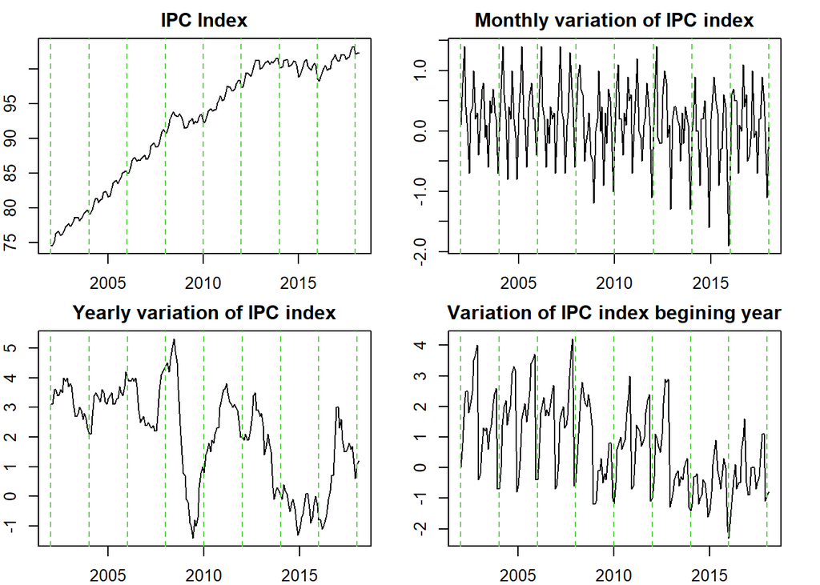

```r
ipcDataRaw = read.csv("_repository/INE_IPC.csv", sep = ",")

# IPC INDEX Transformación
# ----------------------------------
table_range = 1:196
ipcIndex = ipcDataRaw[c(6,7),table_range]
names(ipcIndex) = ipcIndex[1,]
ipcIndex = ipcIndex[-1,] %>% rename(., id = 1) %>% melt(., id = "id") %>% rename(., date = 2, index = 3) %>% .[,2:3] %>% arrange(., desc(date)) %>% transform(., index = as.double(index), date = as.Date(date))
ipcIndex.ts = ts(ipcIndex[2], frequency = 12, start=c(2002,01))

# Monthly variation of IPC index Transformación
# ----------------------------------
table_range = 197:390
IPCmonthVariation = ipcDataRaw[c(6,7),table_range]
names(IPCmonthVariation) = IPCmonthVariation[1,]
IPCmonthVariation = IPCmonthVariation[-1,] %>% rename(., id = 1) %>% melt(., id = "id") %>% rename(., date = 2, index = 3) %>% .[,2:3]  %>% arrange(., desc(date)) %>% transform(., index = as.double(index), date = as.Date(date))
IPCmonthVariation.ts = ts(IPCmonthVariation[2], frequency = 12, start=c(2002,01))

# Yearly variation of IPC index Transformación
# ----------------------------------
table_range = 391:585
IPCyearVariation = ipcDataRaw[c(6,7),table_range]
names(IPCyearVariation) = IPCyearVariation[1,]
IPCyearVariation = IPCyearVariation[-1,] %>% rename(., id = 1) %>% melt(., id = "id") %>% rename(., date = 2, index = 3) %>% .[,2:3] %>% arrange(., desc(date))%>% transform(., index = as.double(index), date = as.Date(date))
IPCyearVariation.ts = ts(IPCyearVariation[2], frequency = 12, start=c(2002,01))

# Variation of IPC index from the begining of the year Transformación
# ----------------------------------
table_range = 586:780
IPCVariationBegining = ipcDataRaw[c(6,7),table_range]
names(IPCVariationBegining) = IPCVariationBegining[1,]
IPCVariationBegining = IPCVariationBegining[-1,] %>% rename(., id = 1) %>% melt(., id = "id") %>% rename(., date = 2, index = 3) %>% .[,2:3] %>% arrange(., desc(date)) %>% transform(., index = as.double(index), date = as.Date(date))
IPCVariationBegining.ts = ts(IPCVariationBegining[2], frequency = 12, start=c(2002,01))


par(mfrow = c(2,2), mar = c(rep(2,4)))
# Plots
# ----------------------------------
plot(ipcIndex.ts, ylab="",main="IPC Index")
abline(v=seq(2002,2019,by=2),lty=2, col = 3)

plot(IPCmonthVariation.ts, ylab="",main="Monthly variation of IPC index")
abline(v=seq(2002,2019,by=2),lty=2, col = 3)

plot(IPCyearVariation.ts, ylab="",main="Yearly variation of IPC index")
abline(v=seq(2002,2019,by=2),lty=2, col = 3)

plot(IPCVariationBegining.ts, ylab="", main="Variation of IPC index begining year")
abline(v=seq(2002,2019,by=2),lty=2, col = 3)
```

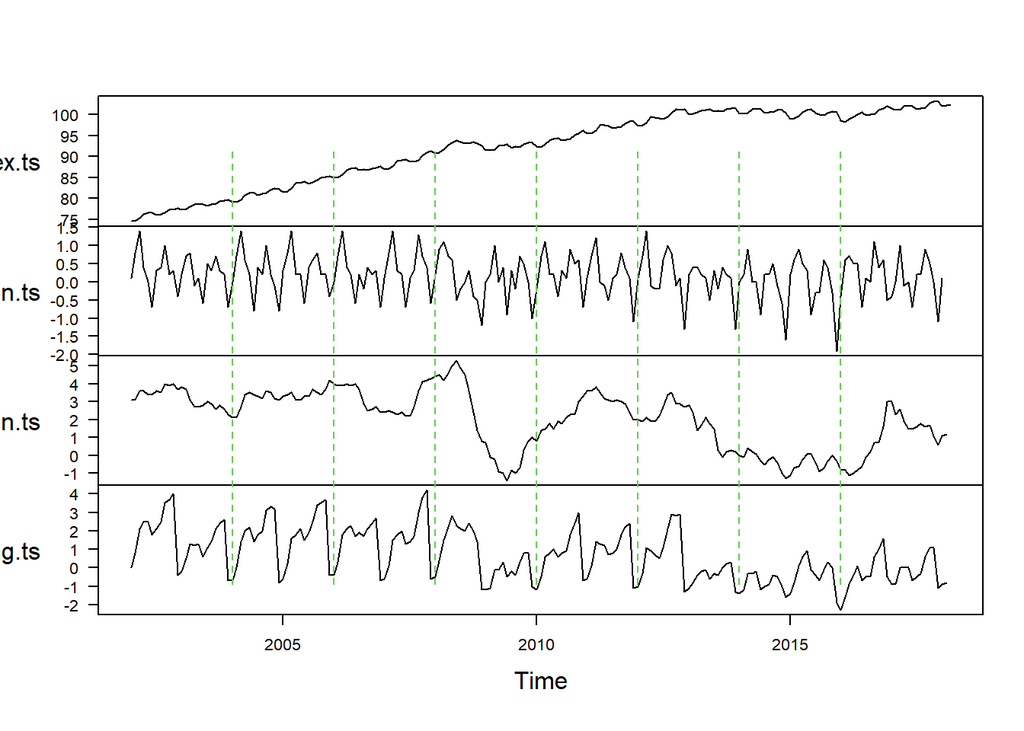

```r
par(mfrow = c(1,1), mar = c(rep(5,4)))

plot(ts.union(ipcIndex.ts, IPCmonthVariation.ts, IPCyearVariation.ts, IPCVariationBegining.ts),  ylab="", main = "", las = 1)
abline(v=seq(2002,2019,by=2),lty=2, col = 3)
```

## Ejercicio 3

**Compute the lag 12 differences of the IPC time series (using function diff). Then plot the union of time series: IPC, its lag 12 differences, and the series containing yearly variation of IPC index we read from file INE_IPC.csv. Do you think that yearly variation of IPC index is stationary in variance?**

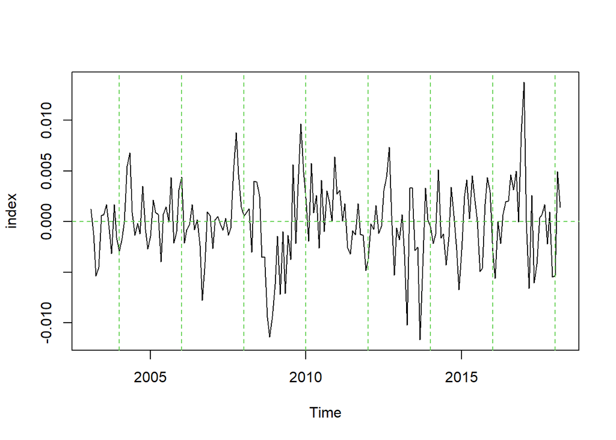

```r
ipcLag12.ts = diff(diff(log(ipcIndex.ts),lag=12))
plot(ipcLag12.ts);abline(v=seq(2002,2019,by=2), h=0, col=3, lty=2)
```

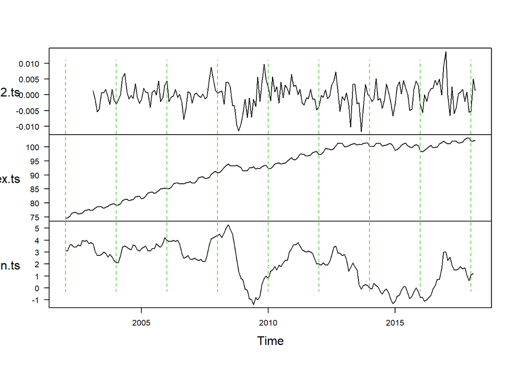

```r
plot(ts.union(ipcLag12.ts, ipcIndex.ts, IPCyearVariation.ts),  ylab="", main = "", las = 1)
abline(v=seq(2002,2019,by=2),lty=2, col = 3)
```

## Ejercicio 4

**Compute the Inflation as Inflation <- 100*diff(IPC,lag=12)/lag(IPC,k=-12).**

**• Is Inflation of class ts?**

**• Why do you think Inflation is so similar to the yearly variation of IPC index?**

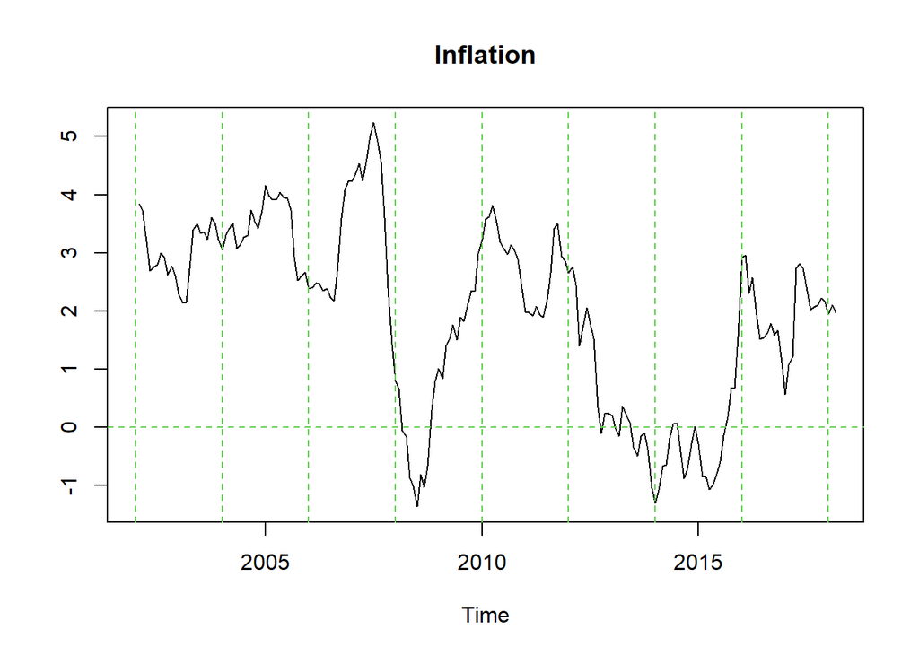

```r
divisor = lag(ipcIndex[,2],k=-12)
#length(divisor)
dividendo = 100*diff(ipcIndex[,2],lag=12)
#length(dividendo)

Inflation = ts(dividendo/divisor, frequency = 12, start=c(2002,01))


plot(Inflation, ylab="",main="Inflation")
abline(h=0, v=seq(2002,2019,by=2),lty=2, col = 3)
```

El IPC nos indica de una cesta de consumo concreta y cerrada de bienes y servicios qué es lo que sucede con los precios (si suben o bajan) de un mes a otro, y no indica los precios en sí mismos. En cambio la inflación es la subida o bajada de los precios de una economía. Se puede ver que estan fuertemente relacionadas y por tanto es lógico que tengan la misma variación.

La inflación es una serie temporal, ya que, son datos recogidos en determinados momentos del tiempo y ordenados cronologicamente.

## Ejercicio 5

**Compute and plot the Autocorrelation Functions (ACFs) of the following time series:**

**• The 4 we read from file INE_IPC.csv.**

**• The inflation time series.**

**• The IPC series after having taken consecutively differences with lags 1 (regular difference) and 12 (seasonal difference).**

**Plot this series previously: diff( diff(IPC,lag=1), lag=12). Do you think it is stationary?**

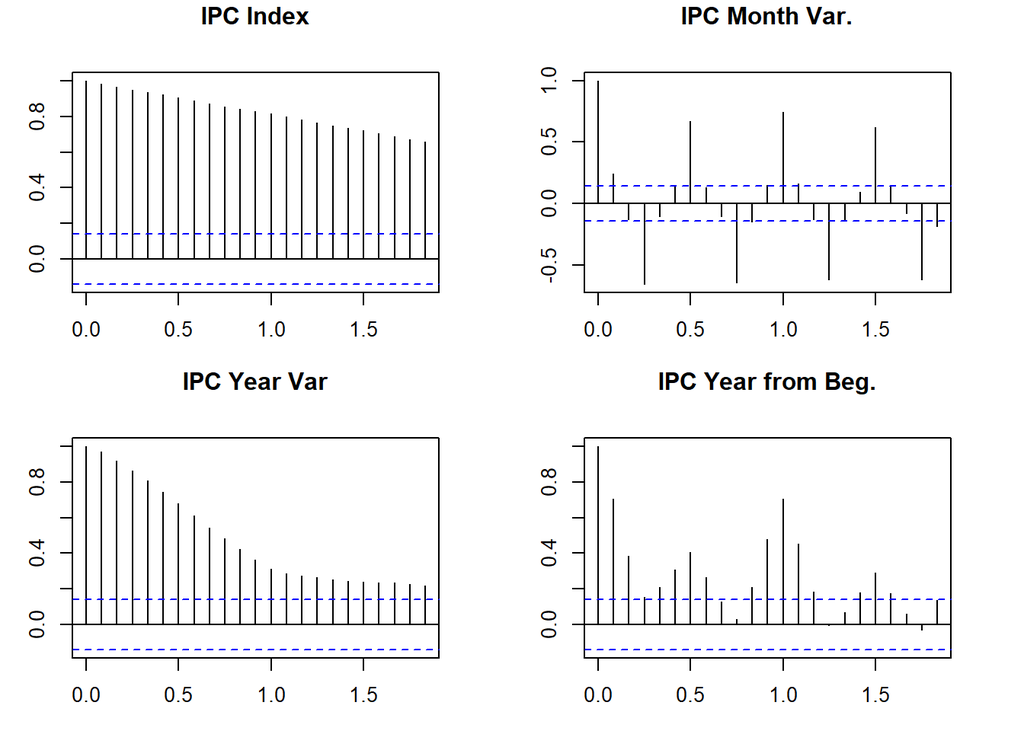

```r
par(mfrow = c(2,2), mar = c(rep(3,4)))

#4 we read from file INE_IPC
# ----------------------------------
acf(ipcIndex.ts, main ="IPC Index")
acf(IPCmonthVariation.ts, main ="IPC Month Var.")
acf(IPCyearVariation.ts, main ="IPC Year Var")
acf(IPCVariationBegining.ts, main ="IPC Year from Beg.")
```

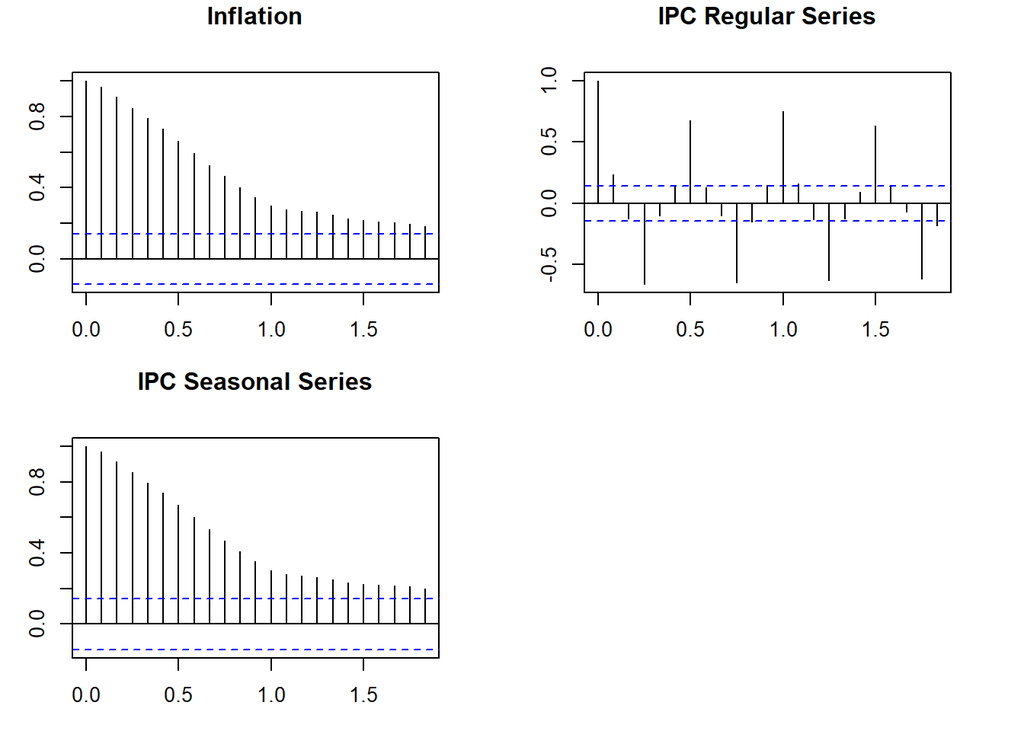

```r
par(mfrow = c(2,2), mar = c(rep(3,4)))
# Inflation
# ----------------------------------
acf(na.omit(Inflation), main ="Inflation")

#IPC Regular series
# ----------------------------------
IPCRegular.ts = diff(log(ipcIndex.ts), lag=1)
acf(IPCRegular.ts, main = "IPC Regular Series")

#IPC Seasonal series
# ----------------------------------
IPCSeasonal.ts =diff(log(ipcIndex.ts),lag=12)
acf(IPCSeasonal.ts, main = "IPC Seasonal Series")

par(mfrow = c(1,1), mar = c(rep(3,4)))
```

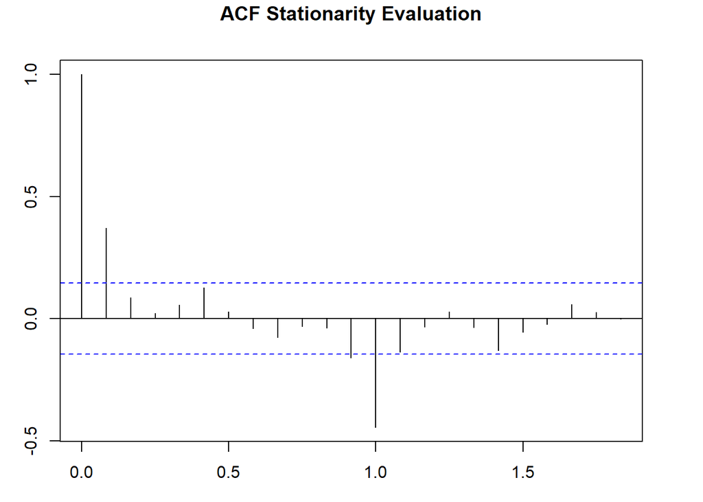

```r
#Plot this series previously:
# ----------------------------------
IPCStationaryEval = diff(diff(ipcIndex.ts,lag=1), lag=12)
acf(IPCStationaryEval, main = "ACF Stationarity Evaluation")
```